# 607_Week2ExtraCredit

Jerald Melukkaran

2025-02-12

### Introduction

In this paper we go through a predictor model and analyse its performance metrics

### Null error rate

This metric lets us know how often we would be wrong if we always predicted the majority class. It gives us a good baseline in predicting the accuracy of a model. If a model’s accuracy is lower than or close to the null error rate, it means the model isn’t doing better than just guessing the majority class. Knowing the majority class also helps us identify how imbalanced the datatype is to see which other performance metrics might be of a greater use.

Formula : 1 - (Majority class count / Total count )

We load the data first from github, calculate the totals to find the majority and then calculate the Null Error Rate

```
## # A tibble: 6 × 3
##   .pred_female .pred_class sex
##          <dbl> <chr>       <chr>
## 1        0.992 female      female
## 2        0.954 female      female
## 3        0.985 female      female
## 4        0.187 male        female
## 5        0.995 female      female
## 6        1.00  female      female
```

```
## Total females: 39
```

```
## Total males: 54
```

```
## Null Error Rate: 0.4193548
```

This lets us know that if we create a predictor that just picks the majority male everytime we would be wrong 41.9% of the time.

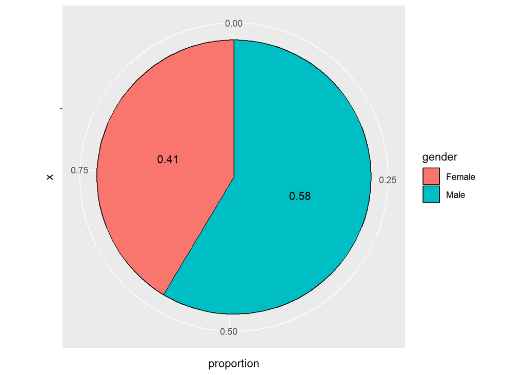

### Confusion Matrix

We use confusion matrices to plot True and False positives and negatives. In this scenario we assume that the sex , prediction being female as postive values. And the sex / prediction being male as negative values.

At the default threshold of 0.5

```
##         Predicted
## Actual   Male Female
##   Male     51      3
##   Female    3     36
## Accuracy: 0.9354839 , Precision:  0.9230769 , recall:  0.9230769  and F1:  0.9230769
```

#### Confusion Matrix at threshold 0.2

Here we alter the predictor to predict female when the .pred_female is over 0.2 instead of 0.5

```
##         Predicted
## Actual   Male Female
##   Male     48      6
##   Female    2     37
## Accuracy: 0.9139785 , Precision:  0.8604651 , recall:  0.9487179  and F1:  0.902439
```

#### Confusion Matrix : threshold 0.8

Here we alter the predictor to predict female when the .pred_female is over 0.8 instead of 0.5

```
##         Predicted
## Actual   Male Female
##   Male     52      2
##   Female    3     36
## Accuracy: 0.9462366 , Precision:  0.9473684 , recall:  0.9230769  and F1:  0.9350649
```

### Results

Now we can compare the effect the different threshold values have on other metrics

```
##   Threshold  Accuracy Precision    Recall  F1_score
## 1       0.5 0.9354839 0.9230769 0.9230769 0.9230769
## 2       0.2 0.9139785 0.8604651 0.9487179 0.9024390
## 3       0.8 0.9462366 0.9473684 0.9230769 0.9350649
```

At 0.2 threshold we can notice that that in this dataset we have a lot more False positives with penguins being classified as females when theyre actualy males. But we also have more true positives with females actually being predicted as females. This would be a good moddel if its more beneficial in predicting false positives to lessen risk factors for eg in a health condition predictor where we would rather have a false positive than a False negative m where someone with the condition is predicted as not having it.

At 0.8 threshhold we get more True negatives where males are being accurately predicted as males. Combining this with the similar number of True positives, this case gives us the highest accuracy. With a more balanced dataset, the accuracy gives a good measure on understanding the quality of the predictor. This also would be beneficial in a situation where predicting true negatives are more important than finding true positives.